# 2강. 데이터 프레임과 분석 기초

- 둘째마당 (04-05)
- pp.074-130 (57쪽)

```python
# 그래프 해상도 설정
import matplotlib.pyplot as plt
plt.rcParams.update({'figure.dpi' : '100'})
%config InlineBackend.figure_format = 'retina'
```

```python
"""
[챗지피티] 2023/12/09
matplotlib이라는 단어의 출처는? -----
"Matplotlib"이라는 단어는 파이썬의 시각화 라이브러리의 이름에서 유래.
"Matplotlib"의 이름은 "MATLAB"이라는 또 다른 기술적 컴퓨팅 환경과 언어에서 영감을 받아서 만들어짐.
MATLAB은 과학 계산과 시각화를 위한 인기 있는 플랫폼.
따라서 "Matplotlib"은 MATLAB의 그래픽 기능을 표현하는 "MAT"과 파이썬의 "Plotting library"를 결합한 이름.
* "Plotting library"란 데이터 시각화를 위해 사용되는 소프트웨어 라이브러리.
   과학적, 교육적, 비즈니스 분석 등 다양한 분야에서 데이터의 패턴, 추세, 관계를 이해하고 설명하는 데 널리 사용.
"""
```

```python
import seaborn  # 패키지 로드
```

```python
var = ['a', 'a', 'b', 'c']
var
```

```
['a', 'a', 'b', 'c']
```

```python
import seaborn as sns
```

```python
"""
[챗지피티] 2023/12/03
Seaborn이라는 파이썬 데이터 시각화 라이브러리는
"웨스트 윙(The West Wing)"이라는 텔레비전 쇼에 등장하는
가상 인물인 Samuel Norman Seaborn의 이름을 따서 명명되었습니다.
이 캐릭터는 배우 Rob Lowe가 연기했으며,
문제에 대해 분석적이고 체계적인 접근 방식으로 알려져 있습니다.
이는 Seaborn 라이브러리가 목표로 하는 매력적이고 유익한
통계 그래픽을 그리기 위한 고급 인터페이스를 제공하는 것과 일치합니다.
이러한 명명법은 프로그래밍 커뮤니티에서 소프트웨어와 라이브러리를
대중 문화 참조로 이름 짓는 경향을 반영합니다.
"""
```

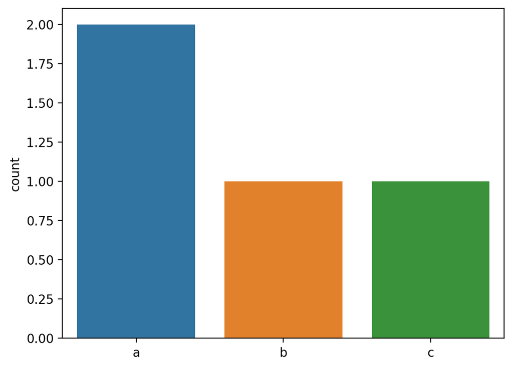

```python
seaborn.countplot(x = var)
```

```python
df = sns.load_dataset('titanic')
df
```

|  | survived | pclass | sex | age | sibsp | parch | fare | embarked | class | who | adult_male | deck | embark_town | alive | alone |
| --- | --- | --- | --- | --- | --- | --- | --- | --- | --- | --- | --- | --- | --- | --- | --- |
| 0 | 0 | 3 | male | 22.0 | 1 | 0 | 7.2500 | S | Third | man | True | NaN | Southampton | no | False |
| 1 | 1 | 1 | female | 38.0 | 1 | 0 | 71.2833 | C | First | woman | False | C | Cherbourg | yes | False |
| 2 | 1 | 3 | female | 26.0 | 0 | 0 | 7.9250 | S | Third | woman | False | NaN | Southampton | yes | True |
| 3 | 1 | 1 | female | 35.0 | 1 | 0 | 53.1000 | S | First | woman | False | C | Southampton | yes | False |
| 4 | 0 | 3 | male | 35.0 | 0 | 0 | 8.0500 | S | Third | man | True | NaN | Southampton | no | True |
| ... | ... | ... | ... | ... | ... | ... | ... | ... | ... | ... | ... | ... | ... | ... | ... |
| 886 | 0 | 2 | male | 27.0 | 0 | 0 | 13.0000 | S | Second | man | True | NaN | Southampton | no | True |
| 887 | 1 | 1 | female | 19.0 | 0 | 0 | 30.0000 | S | First | woman | False | B | Southampton | yes | True |
| 888 | 0 | 3 | female | NaN | 1 | 2 | 23.4500 | S | Third | woman | False | NaN | Southampton | no | False |
| 889 | 1 | 1 | male | 26.0 | 0 | 0 | 30.0000 | C | First | man | True | C | Cherbourg | yes | True |
| 890 | 0 | 3 | male | 32.0 | 0 | 0 | 7.7500 | Q | Third | man | True | NaN | Queenstown | no | True |

891 rows × 15 columns

# 04. 데이터 프레임의 세계로

## 04-1. 데이터 프레임 이해하기(77-80쪽)

- 데이터는 어떻게 생겼나?
- '열'은 속성(변수), '행'은 한 사람[혹은 한 단위]의 정보
- 한 사람의 정보는 가로 한 줄에 나열
- 데이터가 '크다' = 행 또는 열이 '많다'
- 행 보다 '열'이 많은 것이 더 중요
- 빅데이터보다 다양한 데이터가 더 중요

## 04-2. 데이터 프레임 만들기(81-84쪽)

### [Do it! 실습] 데이터 입력해 데이터 프레임 만들기(81쪽)

```python
import pandas as pd
```

```python
# '딕셔너리' 형식('{}')의 데이터를 이용해서 만들기
## -> 딕셔너리에 관하여는 교재 '17-5. 딕셔너리'(418-421쪽) 참조

df = pd.DataFrame({'name':['김지훈', '이유진', '박동현', '김민지'],
                   'english':[90, 80, 60, 70],
                   'math':[50, 60, 100, 20]})                      # DataFrame -> D, F가 대문자
df
```

|  | name | english | math |
| --- | --- | --- | --- |
| 0 | 김지훈 | 90 | 50 |
| 1 | 이유진 | 80 | 60 |
| 2 | 박동현 | 60 | 100 |
| 3 | 김민지 | 70 | 20 |

### [Do it! 실습] 데이터 프레임으로 분석하기(82쪽)

#### 특정 변수의 값 추출하기

```python
df['english']
```

```
0    90
1    80
2    60
3    70
Name: english, dtype: int64
```

#### 변수의 값으로 합계 구하기

```python
sum(df['english'])
```

```
300
```

```python
sum(df['math'])
```

```
230
```

#### 변수의 값으로 평균 구하기

```python
sum(df['english']) / 4
```

```
75.0
```

```python
sum(df['math']) / 4
```

```
57.5
```

## [개인 실습] 혼자서 해보기(84쪽)

### Q1

다음 표의 내용을 데이터 프레임으로 만들어 출력해 보세요 | 제품 | 가격 | 판매량 | |:-----:|:-----:|:------:| | 사과 | 1800 | 24 | | 딸기 | 1500 | 38 | | 수박 | 3000 | 13 |

##### A1

```python
fruit = pd.DataFrame({'제품':['사과', '딸기', '수박'],
              '가격':[1800, 1500, 3000],
              '판매량':[24, 38, 13]
             })
fruit
```

|  | 제품 | 가격 | 판매량 |
| --- | --- | --- | --- |
| 0 | 사과 | 1800 | 24 |
| 1 | 딸기 | 1500 | 38 |
| 2 | 수박 | 3000 | 13 |

### Q2

- 앞에서 만든 데이터 프레임을 이용해 과일의 가격 평균과 판매량 평균을 구하라

##### A2

```python
fruit_average_price = sum(fruit['가격']) / 3
fruit_average_price
```

```
2100.0
```

```python
fruit_average_quantity = sum(fruit['판매량']) / 3
fruit_average_quantity
```

```
25.0
```

## 04-3. 외부 데이터 이용하기(85-92)

- 축적된 시험 성적 데이터를 불러오자!

### [Do it! 실습] 엑셀 파일 불러오기(85쪽)

#### 엑셀 파일 살펴보기

- 깃허브에서 다운로드 (-> 교재 14쪽 참고)

#### 워킹 디렉토리에 엑셀 파일 삽입하기

```python
import pandas as pd

df_exam = pd.read_excel('excel_exam.xlsx')
df_exam
```

|  | id | nclass | math | english | science |
| --- | --- | --- | --- | --- | --- |
| 0 | 1 | 1 | 50 | 98 | 50 |
| 1 | 2 | 1 | 60 | 97 | 60 |
| 2 | 3 | 1 | 45 | 86 | 78 |
| 3 | 4 | 1 | 30 | 98 | 58 |
| 4 | 5 | 2 | 25 | 80 | 65 |
| 5 | 6 | 2 | 50 | 89 | 98 |
| 6 | 7 | 2 | 80 | 90 | 45 |
| 7 | 8 | 2 | 90 | 78 | 25 |
| 8 | 9 | 3 | 20 | 98 | 15 |
| 9 | 10 | 3 | 50 | 98 | 45 |
| 10 | 11 | 3 | 65 | 65 | 65 |
| 11 | 12 | 3 | 45 | 85 | 32 |
| 12 | 13 | 4 | 46 | 98 | 65 |
| 13 | 14 | 4 | 48 | 87 | 12 |
| 14 | 15 | 4 | 75 | 56 | 78 |
| 15 | 16 | 4 | 58 | 98 | 65 |
| 16 | 17 | 5 | 65 | 68 | 98 |
| 17 | 18 | 5 | 80 | 78 | 90 |
| 18 | 19 | 5 | 89 | 68 | 87 |
| 19 | 20 | 5 | 78 | 83 | 58 |

```python
sum(df_exam['english']) / 20
```

```
84.9
```

```python
sum(df_exam['science']) / 20
```

```
59.45
```

```python
# len 사용
x = [1, 2, 3, 4, 5]
len(x)

df = pd.DataFrame({'a':[1,2,3],
                   'b':[4,5,6]
                  })
df
```

|  | a | b |
| --- | --- | --- |
| 0 | 1 | 4 |
| 1 | 2 | 5 |
| 2 | 3 | 6 |

```python
len(df)
```

```
3
```

```python
len(df_exam)
```

```
20
```

```python
sum(df_exam['english']) / len(df_exam)
```

```
84.9
```

```python
sum(df_exam['science']) / len(df_exam)
```

```
59.45
```

```python
# 엑셀 파일의 첫 번째 행이 변수명이 아니라면?

df_exam_novar = pd.read_excel('excel_exam_novar.xlsx')
df_exam_novar
```

|  | 1 | 1.1 | 50 | 98 | 50.1 |
| --- | --- | --- | --- | --- | --- |
| 0 | 2 | 1 | 60 | 97 | 60 |
| 1 | 3 | 2 | 25 | 80 | 65 |
| 2 | 4 | 2 | 50 | 89 | 98 |
| 3 | 5 | 3 | 20 | 98 | 15 |
| 4 | 6 | 3 | 50 | 98 | 45 |
| 5 | 7 | 4 | 46 | 98 | 65 |
| 6 | 8 | 4 | 48 | 87 | 12 |

```python
df_exam_novar = pd.read_excel('excel_exam_novar.xlsx', header=None)
df_exam_novar
```

|  | 0 | 1 | 2 | 3 | 4 |
| --- | --- | --- | --- | --- | --- |
| 0 | 1 | 1 | 50 | 98 | 50 |
| 1 | 2 | 1 | 60 | 97 | 60 |
| 2 | 3 | 2 | 25 | 80 | 65 |
| 3 | 4 | 2 | 50 | 89 | 98 |
| 4 | 5 | 3 | 20 | 98 | 15 |
| 5 | 6 | 3 | 50 | 98 | 45 |
| 6 | 7 | 4 | 46 | 98 | 65 |
| 7 | 8 | 4 | 48 | 87 | 12 |

```python
# CSV 파일 불러오기

df_csv_exam = pd.read_csv('exam.csv')
df_csv_exam
```

|  | id | nclass | math | english | science |
| --- | --- | --- | --- | --- | --- |
| 0 | 1 | 1 | 50 | 98 | 50 |
| 1 | 2 | 1 | 60 | 97 | 60 |
| 2 | 3 | 1 | 45 | 86 | 78 |
| 3 | 4 | 1 | 30 | 98 | 58 |
| 4 | 5 | 2 | 25 | 80 | 65 |
| 5 | 6 | 2 | 50 | 89 | 98 |
| 6 | 7 | 2 | 80 | 90 | 45 |
| 7 | 8 | 2 | 90 | 78 | 25 |
| 8 | 9 | 3 | 20 | 98 | 15 |
| 9 | 10 | 3 | 50 | 98 | 45 |
| 10 | 11 | 3 | 65 | 65 | 65 |
| 11 | 12 | 3 | 45 | 85 | 32 |
| 12 | 13 | 4 | 46 | 98 | 65 |
| 13 | 14 | 4 | 48 | 87 | 12 |
| 14 | 15 | 4 | 75 | 56 | 78 |
| 15 | 16 | 4 | 58 | 98 | 65 |
| 16 | 17 | 5 | 65 | 68 | 98 |
| 17 | 18 | 5 | 80 | 78 | 90 |
| 18 | 19 | 5 | 89 | 68 | 87 |
| 19 | 20 | 5 | 78 | 83 | 58 |

```python
# CSV 파일 저장하기

df_midterm = pd.DataFrame({'english':[90, 80, 60, 70],
                           'math':[50, 60, 100, 20],
                           'nclass':[1, 1, 2, 2]})
df_midterm
```

|  | english | math | nclass |
| --- | --- | --- | --- |
| 0 | 90 | 50 | 1 |
| 1 | 80 | 60 | 1 |
| 2 | 60 | 100 | 2 |
| 3 | 70 | 20 | 2 |

```python
df_midterm.to_csv('output_newdata.csv', index = False) # index = False
```

```python
# 다시 불러오기

reload = pd.read_csv('output_newdata.csv') # index_col = 0 (위에서 인덱스까지 저장했을 경우)
reload
```

|  | english | math | nclass |
| --- | --- | --- | --- |
| 0 | 90 | 50 | 1 |
| 1 | 80 | 60 | 1 |
| 2 | 60 | 100 | 2 |
| 3 | 70 | 20 | 2 |

# 05. 데이터 분석 기초

## 05-1. 데이터 파악하기(99-106쪽)

- head(), tail(), shape, info(), describe()

```python
import pandas as pd
exam = pd.read_csv('exam.csv')
exam
```

|  | id | nclass | math | english | science |
| --- | --- | --- | --- | --- | --- |
| 0 | 1 | 1 | 50 | 98 | 50 |
| 1 | 2 | 1 | 60 | 97 | 60 |
| 2 | 3 | 1 | 45 | 86 | 78 |
| 3 | 4 | 1 | 30 | 98 | 58 |
| 4 | 5 | 2 | 25 | 80 | 65 |
| 5 | 6 | 2 | 50 | 89 | 98 |
| 6 | 7 | 2 | 80 | 90 | 45 |
| 7 | 8 | 2 | 90 | 78 | 25 |
| 8 | 9 | 3 | 20 | 98 | 15 |
| 9 | 10 | 3 | 50 | 98 | 45 |
| 10 | 11 | 3 | 65 | 65 | 65 |
| 11 | 12 | 3 | 45 | 85 | 32 |
| 12 | 13 | 4 | 46 | 98 | 65 |
| 13 | 14 | 4 | 48 | 87 | 12 |
| 14 | 15 | 4 | 75 | 56 | 78 |
| 15 | 16 | 4 | 58 | 98 | 65 |
| 16 | 17 | 5 | 65 | 68 | 98 |
| 17 | 18 | 5 | 80 | 78 | 90 |
| 18 | 19 | 5 | 89 | 68 | 87 |
| 19 | 20 | 5 | 78 | 83 | 58 |

```python
exam.head()
```

|  | id | nclass | math | english | science |
| --- | --- | --- | --- | --- | --- |
| 0 | 1 | 1 | 50 | 98 | 50 |
| 1 | 2 | 1 | 60 | 97 | 60 |
| 2 | 3 | 1 | 45 | 86 | 78 |
| 3 | 4 | 1 | 30 | 98 | 58 |
| 4 | 5 | 2 | 25 | 80 | 65 |

```python
exam.head(10)
```

|  | id | nclass | math | english | science |
| --- | --- | --- | --- | --- | --- |
| 0 | 1 | 1 | 50 | 98 | 50 |
| 1 | 2 | 1 | 60 | 97 | 60 |
| 2 | 3 | 1 | 45 | 86 | 78 |
| 3 | 4 | 1 | 30 | 98 | 58 |
| 4 | 5 | 2 | 25 | 80 | 65 |
| 5 | 6 | 2 | 50 | 89 | 98 |
| 6 | 7 | 2 | 80 | 90 | 45 |
| 7 | 8 | 2 | 90 | 78 | 25 |
| 8 | 9 | 3 | 20 | 98 | 15 |
| 9 | 10 | 3 | 50 | 98 | 45 |

```python
exam.tail()
```

|  | id | nclass | math | english | science |
| --- | --- | --- | --- | --- | --- |
| 15 | 16 | 4 | 58 | 98 | 65 |
| 16 | 17 | 5 | 65 | 68 | 98 |
| 17 | 18 | 5 | 80 | 78 | 90 |
| 18 | 19 | 5 | 89 | 68 | 87 |
| 19 | 20 | 5 | 78 | 83 | 58 |

```python
exam.tail(10)
```

|  | id | nclass | math | english | science |
| --- | --- | --- | --- | --- | --- |
| 10 | 11 | 3 | 65 | 65 | 65 |
| 11 | 12 | 3 | 45 | 85 | 32 |
| 12 | 13 | 4 | 46 | 98 | 65 |
| 13 | 14 | 4 | 48 | 87 | 12 |
| 14 | 15 | 4 | 75 | 56 | 78 |
| 15 | 16 | 4 | 58 | 98 | 65 |
| 16 | 17 | 5 | 65 | 68 | 98 |
| 17 | 18 | 5 | 80 | 78 | 90 |
| 18 | 19 | 5 | 89 | 68 | 87 |
| 19 | 20 | 5 | 78 | 83 | 58 |

```python
exam.shape
```

```
(20, 5)
```

```python
exam.info()
```

```
<class 'pandas.core.frame.DataFrame'>
RangeIndex: 20 entries, 0 to 19
Data columns (total 5 columns):
 #   Column   Non-Null Count  Dtype
---  ------   --------------  -----
 0   id       20 non-null     int64
 1   nclass   20 non-null     int64
 2   math     20 non-null     int64
 3   english  20 non-null     int64
 4   science  20 non-null     int64
dtypes: int64(5)
memory usage: 932.0 bytes
```

```python
exam.describe()
```

|  | id | nclass | math | english | science |
| --- | --- | --- | --- | --- | --- |
| count | 20.00000 | 20.000000 | 20.000000 | 20.000000 | 20.000000 |
| mean | 10.50000 | 3.000000 | 57.450000 | 84.900000 | 59.450000 |
| std | 5.91608 | 1.450953 | 20.299015 | 12.875517 | 25.292968 |
| min | 1.00000 | 1.000000 | 20.000000 | 56.000000 | 12.000000 |
| 25% | 5.75000 | 2.000000 | 45.750000 | 78.000000 | 45.000000 |
| 50% | 10.50000 | 3.000000 | 54.000000 | 86.500000 | 62.500000 |
| 75% | 15.25000 | 4.000000 | 75.750000 | 98.000000 | 78.000000 |
| max | 20.00000 | 5.000000 | 90.000000 | 98.000000 | 98.000000 |

[용어] 사분위

- 사분위간 범위 : 제1 사분위수와 제3 사분위수 간의 거리(Q3-Q1)로, 데이터의 중간 50%에 대한 범위
- https://support.minitab.com/ko-kr/minitab/20/help-and-how-to/graphs/boxplot/interpret-the-results/quartiles/
- 그래프 속 위치

[figure not shown]

```python
# mpg 데이터 불러오기.
'''
cf) mpg : mpg(Mile Per Gallon) 데이터는
미국 환경 보호국(US Environmental Protection Agency)에서 공개한 자료로,
1999~2008년 사이 미국에서 출시된 자동차 234종의 연비 관련 정보를 담고 있다.
https://m.blog.naver.com/eunha4685/221496862666
'''
mpg = pd.read_csv('mpg.csv')
mpg
```

|  | manufacturer | model | displ | year | cyl | trans | drv | cty | hwy | fl | category |
| --- | --- | --- | --- | --- | --- | --- | --- | --- | --- | --- | --- |
| 0 | audi | a4 | 1.8 | 1999 | 4 | auto(l5) | f | 18 | 29 | p | compact |
| 1 | audi | a4 | 1.8 | 1999 | 4 | manual(m5) | f | 21 | 29 | p | compact |
| 2 | audi | a4 | 2.0 | 2008 | 4 | manual(m6) | f | 20 | 31 | p | compact |
| 3 | audi | a4 | 2.0 | 2008 | 4 | auto(av) | f | 21 | 30 | p | compact |
| 4 | audi | a4 | 2.8 | 1999 | 6 | auto(l5) | f | 16 | 26 | p | compact |
| ... | ... | ... | ... | ... | ... | ... | ... | ... | ... | ... | ... |
| 229 | volkswagen | passat | 2.0 | 2008 | 4 | auto(s6) | f | 19 | 28 | p | midsize |
| 230 | volkswagen | passat | 2.0 | 2008 | 4 | manual(m6) | f | 21 | 29 | p | midsize |
| 231 | volkswagen | passat | 2.8 | 1999 | 6 | auto(l5) | f | 16 | 26 | p | midsize |
| 232 | volkswagen | passat | 2.8 | 1999 | 6 | manual(m5) | f | 18 | 26 | p | midsize |
| 233 | volkswagen | passat | 3.6 | 2008 | 6 | auto(s6) | f | 17 | 26 | p | midsize |

234 rows × 11 columns

```python
mpg.head()
```

|  | manufacturer | model | displ | year | cyl | trans | drv | cty | hwy | fl | category |
| --- | --- | --- | --- | --- | --- | --- | --- | --- | --- | --- | --- |
| 0 | audi | a4 | 1.8 | 1999 | 4 | auto(l5) | f | 18 | 29 | p | compact |
| 1 | audi | a4 | 1.8 | 1999 | 4 | manual(m5) | f | 21 | 29 | p | compact |
| 2 | audi | a4 | 2.0 | 2008 | 4 | manual(m6) | f | 20 | 31 | p | compact |
| 3 | audi | a4 | 2.0 | 2008 | 4 | auto(av) | f | 21 | 30 | p | compact |
| 4 | audi | a4 | 2.8 | 1999 | 6 | auto(l5) | f | 16 | 26 | p | compact |

```python
mpg.tail()
```

|  | manufacturer | model | displ | year | cyl | trans | drv | cty | hwy | fl | category |
| --- | --- | --- | --- | --- | --- | --- | --- | --- | --- | --- | --- |
| 229 | volkswagen | passat | 2.0 | 2008 | 4 | auto(s6) | f | 19 | 28 | p | midsize |
| 230 | volkswagen | passat | 2.0 | 2008 | 4 | manual(m6) | f | 21 | 29 | p | midsize |
| 231 | volkswagen | passat | 2.8 | 1999 | 6 | auto(l5) | f | 16 | 26 | p | midsize |
| 232 | volkswagen | passat | 2.8 | 1999 | 6 | manual(m5) | f | 18 | 26 | p | midsize |
| 233 | volkswagen | passat | 3.6 | 2008 | 6 | auto(s6) | f | 17 | 26 | p | midsize |

```python
mpg.shape
```

```
(234, 11)
```

```python
mpg.info()
```

```
<class 'pandas.core.frame.DataFrame'>
RangeIndex: 234 entries, 0 to 233
Data columns (total 11 columns):
 #   Column        Non-Null Count  Dtype
---  ------        --------------  -----
 0   manufacturer  234 non-null    object
 1   model         234 non-null    object
 2   displ         234 non-null    float64
 3   year          234 non-null    int64
 4   cyl           234 non-null    int64
 5   trans         234 non-null    object
 6   drv           234 non-null    object
 7   cty           234 non-null    int64
 8   hwy           234 non-null    int64
 9   fl            234 non-null    object
 10  category      234 non-null    object
dtypes: float64(1), int64(4), object(6)
memory usage: 20.2+ KB
```

```python
mpg.describe()
```

|  | displ | year | cyl | cty | hwy |
| --- | --- | --- | --- | --- | --- |
| count | 234.000000 | 234.000000 | 234.000000 | 234.000000 | 234.000000 |
| mean | 3.471795 | 2003.500000 | 5.888889 | 16.858974 | 23.440171 |
| std | 1.291959 | 4.509646 | 1.611534 | 4.255946 | 5.954643 |
| min | 1.600000 | 1999.000000 | 4.000000 | 9.000000 | 12.000000 |
| 25% | 2.400000 | 1999.000000 | 4.000000 | 14.000000 | 18.000000 |
| 50% | 3.300000 | 2003.500000 | 6.000000 | 17.000000 | 24.000000 |
| 75% | 4.600000 | 2008.000000 | 8.000000 | 19.000000 | 27.000000 |
| max | 7.000000 | 2008.000000 | 8.000000 | 35.000000 | 44.000000 |

```python
mpg.describe(include='object')
```

|  | manufacturer | model | trans | drv | fl | category |
| --- | --- | --- | --- | --- | --- | --- |
| count | 234 | 234 | 234 | 234 | 234 | 234 |
| unique | 15 | 38 | 10 | 3 | 5 | 7 |
| top | dodge | caravan 2wd | auto(l4) | f | r | suv |
| freq | 37 | 11 | 83 | 106 | 168 | 62 |

```python
mpg.describe(include='all')
```

|  | manufacturer | model | displ | year | cyl | trans | drv | cty | hwy | fl | category |
| --- | --- | --- | --- | --- | --- | --- | --- | --- | --- | --- | --- |
| count | 234 | 234 | 234.000000 | 234.000000 | 234.000000 | 234 | 234 | 234.000000 | 234.000000 | 234 | 234 |
| unique | 15 | 38 | NaN | NaN | NaN | 10 | 3 | NaN | NaN | 5 | 7 |
| top | dodge | caravan 2wd | NaN | NaN | NaN | auto(l4) | f | NaN | NaN | r | suv |
| freq | 37 | 11 | NaN | NaN | NaN | 83 | 106 | NaN | NaN | 168 | 62 |
| mean | NaN | NaN | 3.471795 | 2003.500000 | 5.888889 | NaN | NaN | 16.858974 | 23.440171 | NaN | NaN |
| std | NaN | NaN | 1.291959 | 4.509646 | 1.611534 | NaN | NaN | 4.255946 | 5.954643 | NaN | NaN |
| min | NaN | NaN | 1.600000 | 1999.000000 | 4.000000 | NaN | NaN | 9.000000 | 12.000000 | NaN | NaN |
| 25% | NaN | NaN | 2.400000 | 1999.000000 | 4.000000 | NaN | NaN | 14.000000 | 18.000000 | NaN | NaN |
| 50% | NaN | NaN | 3.300000 | 2003.500000 | 6.000000 | NaN | NaN | 17.000000 | 24.000000 | NaN | NaN |
| 75% | NaN | NaN | 4.600000 | 2008.000000 | 8.000000 | NaN | NaN | 19.000000 | 27.000000 | NaN | NaN |
| max | NaN | NaN | 7.000000 | 2008.000000 | 8.000000 | NaN | NaN | 35.000000 | 44.000000 | NaN | NaN |

cf) 함수(내장함수, 패키지 함수), 메서드, 어트리뷰트

- 내장 함수 : 가장 기본적인 함수로 파이썬에 내장. 함수명 및 괄호 입력해서 사용. ex) sum(var)
- 패키지 함수 : 패키지를 로드해야 사용. 패키지명 뒤에 점 찍고 함수명 및 괄호 입력해서 사용.  
  ex) pd.DataFrame({'x':[1, 2, 3]})
- 메서드 : '변수가 지니고 있는 함수'. 변수명 뒤에 점 찍고 메서드명 및 괄호 입력해서 사용.  
  ex) df.head()  
  = 변수의 자료구조에 따라 사용할 수 있는 메서드가 다르다.
- 어트리뷰트 : '변수가 지니고 있는 값'. 변수명 뒤에 점 찍고 어트리뷰트명 입력해서 사용. 괄호 X  
  ex) df.shape ; df.index ; df.columns  
  = 이 역시 변수의 자료구조에 따라 사용할 수 있는 어트리뷰트가 다르다.

## 05-2. 변수명 바꾸기(113-115쪽)

- 목적 : 변수명을 이해하기 쉬운 단어로 변경 -> 데이터를 수월하게 다룰 수 있음
- df.rename()

```python
df_raw = pd.DataFrame({'var1':[1, 2, 1],
                       'var2':[2, 3, 2],})
df_raw
```

|  | var1 | var2 |
| --- | --- | --- |
| 0 | 1 | 2 |
| 1 | 2 | 3 |
| 2 | 1 | 2 |

```python
df_new = df_raw.copy()
df_new
```

|  | var1 | var2 |
| --- | --- | --- |
| 0 | 1 | 2 |
| 1 | 2 | 3 |
| 2 | 1 | 2 |

```python
df_new = df_new.rename(columns = {'var2' : 'v2'}) # var2를 v2로 수정
df_new
```

|  | var1 | v2 |
| --- | --- | --- |
| 0 | 1 | 2 |
| 1 | 2 | 3 |
| 2 | 1 | 2 |

### [개인 실습] 혼자서 해보기(115쪽)

- mpg 데이터의 변수명은 긴 단어를 짧게 줄인 축약어로 되어 있다. cty는 도시 연비, hwy는 고속도로 연비를 의미한다. 변수명을 이해하기 쉬운 단어로 바꾸려 한다.

#### Q1 : mpg 데이터를 불러와 복사본을 만드세요.

```python
mpg_new = mpg.copy()
mpg_new
```

|  | manufacturer | model | displ | year | cyl | trans | drv | cty | hwy | fl | category |
| --- | --- | --- | --- | --- | --- | --- | --- | --- | --- | --- | --- |
| 0 | audi | a4 | 1.8 | 1999 | 4 | auto(l5) | f | 18 | 29 | p | compact |
| 1 | audi | a4 | 1.8 | 1999 | 4 | manual(m5) | f | 21 | 29 | p | compact |
| 2 | audi | a4 | 2.0 | 2008 | 4 | manual(m6) | f | 20 | 31 | p | compact |
| 3 | audi | a4 | 2.0 | 2008 | 4 | auto(av) | f | 21 | 30 | p | compact |
| 4 | audi | a4 | 2.8 | 1999 | 6 | auto(l5) | f | 16 | 26 | p | compact |
| ... | ... | ... | ... | ... | ... | ... | ... | ... | ... | ... | ... |
| 229 | volkswagen | passat | 2.0 | 2008 | 4 | auto(s6) | f | 19 | 28 | p | midsize |
| 230 | volkswagen | passat | 2.0 | 2008 | 4 | manual(m6) | f | 21 | 29 | p | midsize |
| 231 | volkswagen | passat | 2.8 | 1999 | 6 | auto(l5) | f | 16 | 26 | p | midsize |
| 232 | volkswagen | passat | 2.8 | 1999 | 6 | manual(m5) | f | 18 | 26 | p | midsize |
| 233 | volkswagen | passat | 3.6 | 2008 | 6 | auto(s6) | f | 17 | 26 | p | midsize |

234 rows × 11 columns

#### Q2 : 복사본 데이터를 이용해 cty는 city로, hwy는 highway로 수정하세요

```python
mpg_new = mpg_new.rename(columns = {'cty' : 'city',
                                    'hwy' : 'highway'})
mpg_new
```

|  | manufacturer | model | displ | year | cyl | trans | drv | city | highway | fl | category |
| --- | --- | --- | --- | --- | --- | --- | --- | --- | --- | --- | --- |
| 0 | audi | a4 | 1.8 | 1999 | 4 | auto(l5) | f | 18 | 29 | p | compact |
| 1 | audi | a4 | 1.8 | 1999 | 4 | manual(m5) | f | 21 | 29 | p | compact |
| 2 | audi | a4 | 2.0 | 2008 | 4 | manual(m6) | f | 20 | 31 | p | compact |
| 3 | audi | a4 | 2.0 | 2008 | 4 | auto(av) | f | 21 | 30 | p | compact |
| 4 | audi | a4 | 2.8 | 1999 | 6 | auto(l5) | f | 16 | 26 | p | compact |
| ... | ... | ... | ... | ... | ... | ... | ... | ... | ... | ... | ... |
| 229 | volkswagen | passat | 2.0 | 2008 | 4 | auto(s6) | f | 19 | 28 | p | midsize |
| 230 | volkswagen | passat | 2.0 | 2008 | 4 | manual(m6) | f | 21 | 29 | p | midsize |
| 231 | volkswagen | passat | 2.8 | 1999 | 6 | auto(l5) | f | 16 | 26 | p | midsize |
| 232 | volkswagen | passat | 2.8 | 1999 | 6 | manual(m5) | f | 18 | 26 | p | midsize |
| 233 | volkswagen | passat | 3.6 | 2008 | 6 | auto(s6) | f | 17 | 26 | p | midsize |

234 rows × 11 columns

## 05-3. 파생변수 만들기(116-128쪽)

```python
import pandas as pd

df = pd.DataFrame({'var1':[4, 3, 8],
                   'var2':[2, 6, 1]})
df
```

|  | var1 | var2 |
| --- | --- | --- |
| 0 | 4 | 2 |
| 1 | 3 | 6 |
| 2 | 8 | 1 |

```python
df['var_sum'] = df['var1'] + df['var2']
df
```

|  | var1 | var2 | var_sum |
| --- | --- | --- | --- |
| 0 | 4 | 2 | 6 |
| 1 | 3 | 6 | 9 |
| 2 | 8 | 1 | 9 |

```python
df['var_mean'] = (df['var1'] + df['var2']) / 2
df
```

|  | var1 | var2 | var_sum | var_mean |
| --- | --- | --- | --- | --- |
| 0 | 4 | 2 | 6 | 3.0 |
| 1 | 3 | 6 | 9 | 4.5 |
| 2 | 8 | 1 | 9 | 4.5 |

```python
# 실습 : mpg 통합 연비 변수 만들기 (117쪽)

mpg = pd.read_csv('mpg.csv')
mpg
```

|  | manufacturer | model | displ | year | cyl | trans | drv | cty | hwy | fl | category |
| --- | --- | --- | --- | --- | --- | --- | --- | --- | --- | --- | --- |
| 0 | audi | a4 | 1.8 | 1999 | 4 | auto(l5) | f | 18 | 29 | p | compact |
| 1 | audi | a4 | 1.8 | 1999 | 4 | manual(m5) | f | 21 | 29 | p | compact |
| 2 | audi | a4 | 2.0 | 2008 | 4 | manual(m6) | f | 20 | 31 | p | compact |
| 3 | audi | a4 | 2.0 | 2008 | 4 | auto(av) | f | 21 | 30 | p | compact |
| 4 | audi | a4 | 2.8 | 1999 | 6 | auto(l5) | f | 16 | 26 | p | compact |
| ... | ... | ... | ... | ... | ... | ... | ... | ... | ... | ... | ... |
| 229 | volkswagen | passat | 2.0 | 2008 | 4 | auto(s6) | f | 19 | 28 | p | midsize |
| 230 | volkswagen | passat | 2.0 | 2008 | 4 | manual(m6) | f | 21 | 29 | p | midsize |
| 231 | volkswagen | passat | 2.8 | 1999 | 6 | auto(l5) | f | 16 | 26 | p | midsize |
| 232 | volkswagen | passat | 2.8 | 1999 | 6 | manual(m5) | f | 18 | 26 | p | midsize |
| 233 | volkswagen | passat | 3.6 | 2008 | 6 | auto(s6) | f | 17 | 26 | p | midsize |

234 rows × 11 columns

```python
mpg['total'] = (mpg['cty'] + mpg['hwy']) / 2
mpg.head()
```

|  | manufacturer | model | displ | year | cyl | trans | drv | cty | hwy | fl | category | total |
| --- | --- | --- | --- | --- | --- | --- | --- | --- | --- | --- | --- | --- |
| 0 | audi | a4 | 1.8 | 1999 | 4 | auto(l5) | f | 18 | 29 | p | compact | 23.5 |
| 1 | audi | a4 | 1.8 | 1999 | 4 | manual(m5) | f | 21 | 29 | p | compact | 25.0 |
| 2 | audi | a4 | 2.0 | 2008 | 4 | manual(m6) | f | 20 | 31 | p | compact | 25.5 |
| 3 | audi | a4 | 2.0 | 2008 | 4 | auto(av) | f | 21 | 30 | p | compact | 25.5 |
| 4 | audi | a4 | 2.8 | 1999 | 6 | auto(l5) | f | 16 | 26 | p | compact | 21.0 |

```python
sum(mpg['total']) / len(mpg['total'])
```

```
20.14957264957265
```

```python
mpg['total'].mean()
```

```
20.14957264957265
```

```python
# 조건물을 활용해 파생변수 만들기
## 1) 기준값 정하기

mpg['total'].describe()
```

```
count    234.000000
mean      20.149573
std        5.050290
min       10.500000
25%       15.500000
50%       20.500000
75%       23.500000
max       39.500000
Name: total, dtype: float64
```

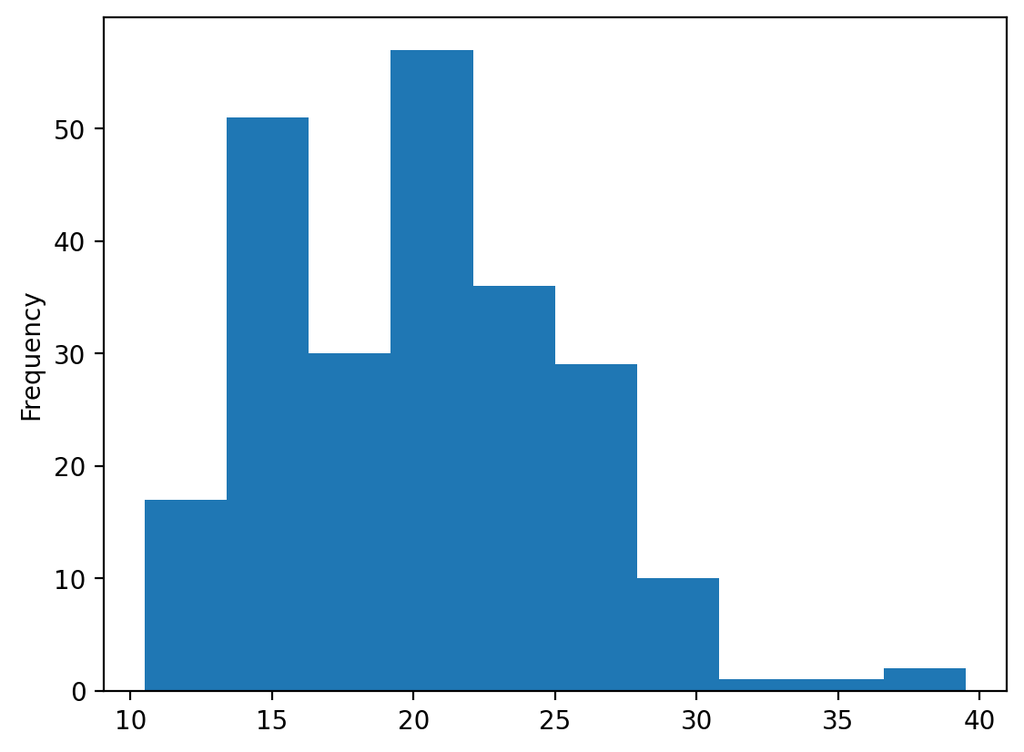

```python
mpg['total'].plot.hist()
```

```python
## 2. 합격 판정 변수 만들기

import numpy as np
```

```python
mpg['test'] = np.where(mpg['total'] >= 20, 'pass', 'fail')
mpg.head()
```

|  | manufacturer | model | displ | year | cyl | trans | drv | cty | hwy | fl | category | total | test |
| --- | --- | --- | --- | --- | --- | --- | --- | --- | --- | --- | --- | --- | --- |
| 0 | audi | a4 | 1.8 | 1999 | 4 | auto(l5) | f | 18 | 29 | p | compact | 23.5 | pass |
| 1 | audi | a4 | 1.8 | 1999 | 4 | manual(m5) | f | 21 | 29 | p | compact | 25.0 | pass |
| 2 | audi | a4 | 2.0 | 2008 | 4 | manual(m6) | f | 20 | 31 | p | compact | 25.5 | pass |
| 3 | audi | a4 | 2.0 | 2008 | 4 | auto(av) | f | 21 | 30 | p | compact | 25.5 | pass |
| 4 | audi | a4 | 2.8 | 1999 | 6 | auto(l5) | f | 16 | 26 | p | compact | 21.0 | pass |

```python
## 3. 빈도표로 합격 판정 자동차 수 살펴보기

mpg['test'].value_counts()
```

```
test
pass    128
fail    106
Name: count, dtype: int64
```

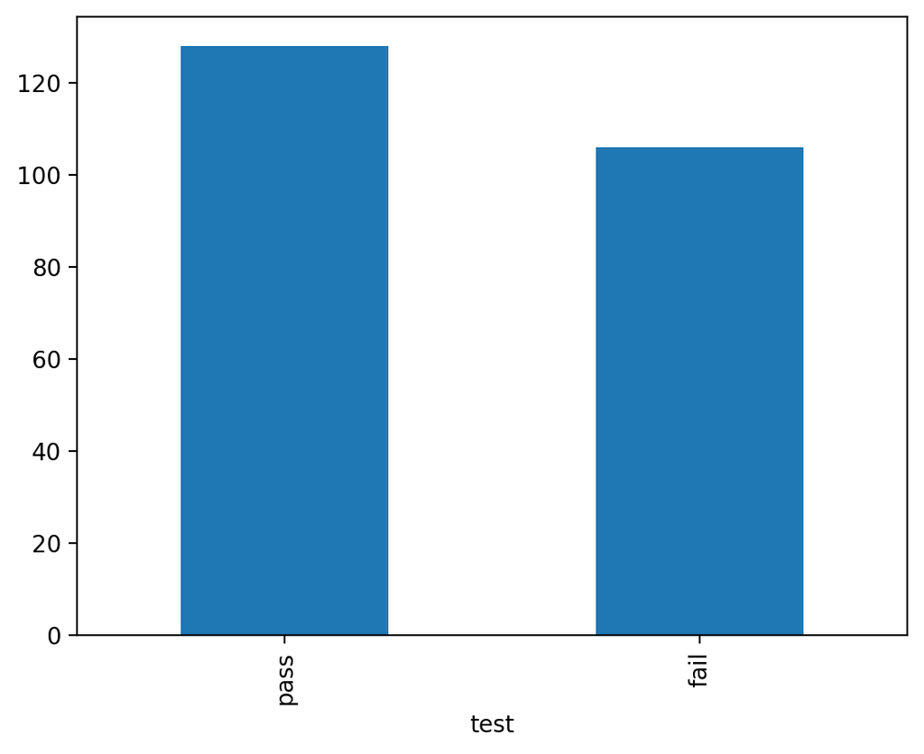

```python
## 4. 막대 그래프로 빈도 표현하기

count_test = mpg['test'].value_counts()
count_test.plot.bar()
```

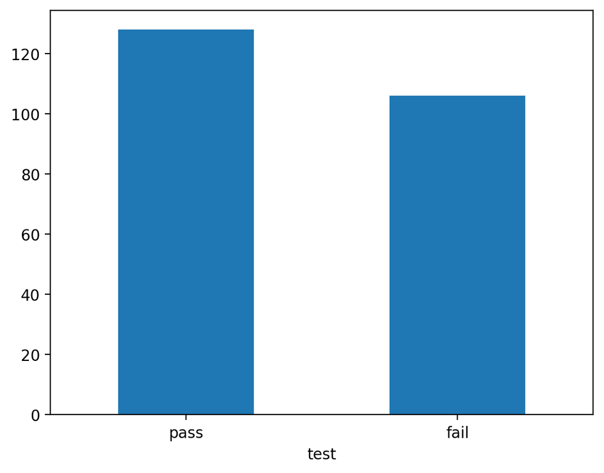

```python
### 축 이름 회전하기

count_test.plot.bar(rot = 0)
```

```python
# 실습 : 중첩 조건문 활용하기 (123쪽)

## 1. 연비 등급 변수 만들기
```

```python
# total 기준으로 A, B, C 등급 부여
mpg['grade'] = np.where(mpg['total'] >= 30, 'A',
               np.where(mpg['total'] >= 20, 'B', 'C'))

# 데이터 확인
mpg.head()
```

|  | manufacturer | model | displ | year | cyl | trans | drv | cty | hwy | fl | category | total | test | grade |
| --- | --- | --- | --- | --- | --- | --- | --- | --- | --- | --- | --- | --- | --- | --- |
| 0 | audi | a4 | 1.8 | 1999 | 4 | auto(l5) | f | 18 | 29 | p | compact | 23.5 | pass | B |
| 1 | audi | a4 | 1.8 | 1999 | 4 | manual(m5) | f | 21 | 29 | p | compact | 25.0 | pass | B |
| 2 | audi | a4 | 2.0 | 2008 | 4 | manual(m6) | f | 20 | 31 | p | compact | 25.5 | pass | B |
| 3 | audi | a4 | 2.0 | 2008 | 4 | auto(av) | f | 21 | 30 | p | compact | 25.5 | pass | B |
| 4 | audi | a4 | 2.8 | 1999 | 6 | auto(l5) | f | 16 | 26 | p | compact | 21.0 | pass | B |

```python
## 2. 빈도표와 막대 그래프로 연비 등급 살펴보기

count_grade = mpg['grade'].value_counts()
count_grade
```

```
grade
B    118
C    106
A     10
Name: count, dtype: int64
```

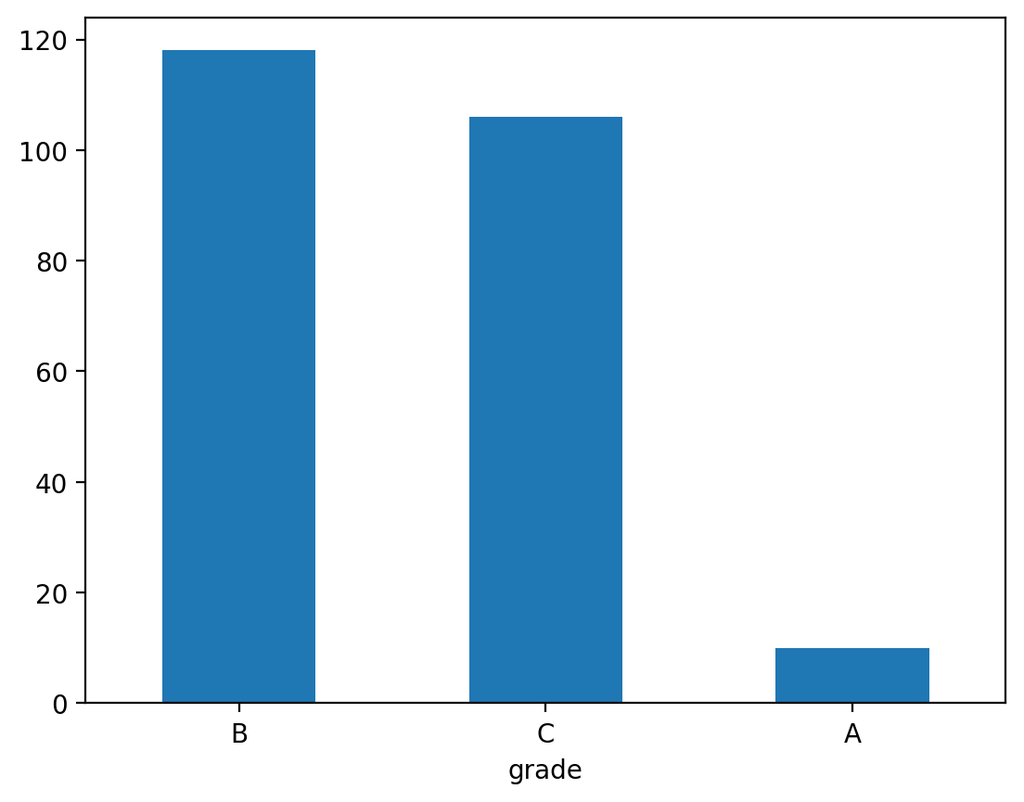

```python
count_grade.plot.bar(rot = 0)
```

```python
# 알파벳 순으로 막대 정렬하기

count_grade = mpg['grade'].value_counts().sort_index()
count_grade
```

```
grade
A     10
B    118
C    106
Name: count, dtype: int64
```

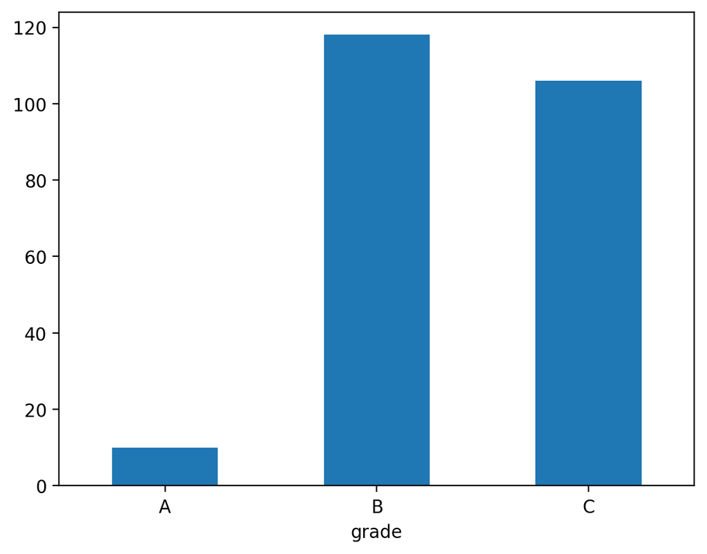

```python
count_grade.plot.bar(rot = 0)
```

```python
# 메서드 체이닝
```

```python
# A, B, C, D 등급 변수 만들기

mpg['grade2'] = np.where(mpg['total'] >= 30, 'A',
                np.where(mpg['total'] >= 25, 'B',
                np.where(mpg['total'] >= 20, 'C', 'D')))
mpg
```

|  | manufacturer | model | displ | year | cyl | trans | drv | cty | hwy | fl | category | total | test | grade | grade2 |
| --- | --- | --- | --- | --- | --- | --- | --- | --- | --- | --- | --- | --- | --- | --- | --- |
| 0 | audi | a4 | 1.8 | 1999 | 4 | auto(l5) | f | 18 | 29 | p | compact | 23.5 | pass | B | C |
| 1 | audi | a4 | 1.8 | 1999 | 4 | manual(m5) | f | 21 | 29 | p | compact | 25.0 | pass | B | B |
| 2 | audi | a4 | 2.0 | 2008 | 4 | manual(m6) | f | 20 | 31 | p | compact | 25.5 | pass | B | B |
| 3 | audi | a4 | 2.0 | 2008 | 4 | auto(av) | f | 21 | 30 | p | compact | 25.5 | pass | B | B |
| 4 | audi | a4 | 2.8 | 1999 | 6 | auto(l5) | f | 16 | 26 | p | compact | 21.0 | pass | B | C |
| ... | ... | ... | ... | ... | ... | ... | ... | ... | ... | ... | ... | ... | ... | ... | ... |
| 229 | volkswagen | passat | 2.0 | 2008 | 4 | auto(s6) | f | 19 | 28 | p | midsize | 23.5 | pass | B | C |
| 230 | volkswagen | passat | 2.0 | 2008 | 4 | manual(m6) | f | 21 | 29 | p | midsize | 25.0 | pass | B | B |
| 231 | volkswagen | passat | 2.8 | 1999 | 6 | auto(l5) | f | 16 | 26 | p | midsize | 21.0 | pass | B | C |
| 232 | volkswagen | passat | 2.8 | 1999 | 6 | manual(m5) | f | 18 | 26 | p | midsize | 22.0 | pass | B | C |
| 233 | volkswagen | passat | 3.6 | 2008 | 6 | auto(s6) | f | 17 | 26 | p | midsize | 21.5 | pass | B | C |

234 rows × 15 columns

```python
count_grade_2 = mpg['grade2'].value_counts().sort_index()
count_grade_2
```

```
grade2
A     10
B     33
C     85
D    106
Name: count, dtype: int64
```

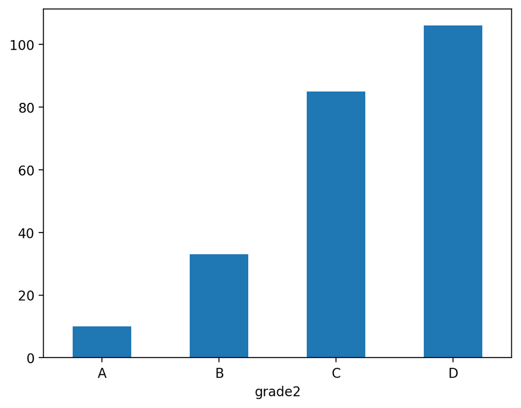

```python
count_grade_2.plot.bar(rot=0)
```

### [Do it! 실습] 목록에 해당하는 행으로 변수 만들기(128쪽)

```python
mpg['size'] = np.where((mpg['category'] == 'compact') |
                       (mpg['category'] == 'subcompact') |
                       (mpg['category'] == '2seater'),
                       'small', 'large')
mpg['size'].value_counts()
```

```
size
large    147
small     87
Name: count, dtype: int64
```

```python
# np.where() -> df.isin()

mpg['size'] = np.where(mpg['category'].isin(['compact', 'subcompact', '2seater']), 'small', 'large')
mpg['size'].value_counts()
```

```
size
large    147
small     87
Name: count, dtype: int64
```

### [분석 도전]

- midwest.csv는 미국 동북중부(East North Central States) 437개 지역의 인구통계 정보를 담고 있습니다. midwest.csv를 이용해 데이터 분석 문제를 해결해 보세요.
- midwest 데이터 출처: bit.ly/easypy_52

#### 문제1

- midwest.csv를 불러와 데이터의 특징을 파악하세요

```python
midwest = pd.read_csv('midwest.csv')
midwest
```

|  | PID | county | state | area | poptotal | popdensity | popwhite | popblack | popamerindian | popasian | ... | percollege | percprof | poppovertyknown | percpovertyknown | percbelowpoverty | percchildbelowpovert | percadultpoverty | percelderlypoverty | inmetro | category |
| --- | --- | --- | --- | --- | --- | --- | --- | --- | --- | --- | --- | --- | --- | --- | --- | --- | --- | --- | --- | --- | --- |
| 0 | 561 | ADAMS | IL | 0.052 | 66090 | 1270.961540 | 63917 | 1702 | 98 | 249 | ... | 19.631392 | 4.355859 | 63628 | 96.274777 | 13.151443 | 18.011717 | 11.009776 | 12.443812 | 0 | AAR |
| 1 | 562 | ALEXANDER | IL | 0.014 | 10626 | 759.000000 | 7054 | 3496 | 19 | 48 | ... | 11.243308 | 2.870315 | 10529 | 99.087145 | 32.244278 | 45.826514 | 27.385647 | 25.228976 | 0 | LHR |
| 2 | 563 | BOND | IL | 0.022 | 14991 | 681.409091 | 14477 | 429 | 35 | 16 | ... | 17.033819 | 4.488572 | 14235 | 94.956974 | 12.068844 | 14.036061 | 10.852090 | 12.697410 | 0 | AAR |
| 3 | 564 | BOONE | IL | 0.017 | 30806 | 1812.117650 | 29344 | 127 | 46 | 150 | ... | 17.278954 | 4.197800 | 30337 | 98.477569 | 7.209019 | 11.179536 | 5.536013 | 6.217047 | 1 | ALU |
| 4 | 565 | BROWN | IL | 0.018 | 5836 | 324.222222 | 5264 | 547 | 14 | 5 | ... | 14.475999 | 3.367680 | 4815 | 82.505140 | 13.520249 | 13.022889 | 11.143211 | 19.200000 | 0 | AAR |
| ... | ... | ... | ... | ... | ... | ... | ... | ... | ... | ... | ... | ... | ... | ... | ... | ... | ... | ... | ... | ... | ... |
| 432 | 3048 | WAUKESHA | WI | 0.034 | 304715 | 8962.205880 | 298313 | 1096 | 672 | 2699 | ... | 35.396784 | 7.667090 | 299802 | 98.387674 | 3.121060 | 3.785820 | 2.590061 | 4.085479 | 1 | HLU |
| 433 | 3049 | WAUPACA | WI | 0.045 | 46104 | 1024.533330 | 45695 | 22 | 125 | 92 | ... | 16.549869 | 3.138596 | 44412 | 96.330036 | 8.488697 | 10.071411 | 6.953799 | 10.338641 | 0 | AAR |
| 434 | 3050 | WAUSHARA | WI | 0.037 | 19385 | 523.918919 | 19094 | 29 | 70 | 43 | ... | 15.064584 | 2.620907 | 19163 | 98.854785 | 13.786985 | 20.050708 | 11.695784 | 11.804558 | 0 | AAR |
| 435 | 3051 | WINNEBAGO | WI | 0.035 | 140320 | 4009.142860 | 136822 | 697 | 685 | 1728 | ... | 24.995504 | 5.659847 | 133950 | 95.460376 | 8.804031 | 10.592031 | 8.660587 | 6.661094 | 1 | HAU |
| 436 | 3052 | WOOD | WI | 0.048 | 73605 | 1533.437500 | 72157 | 90 | 481 | 722 | ... | 21.666382 | 4.583725 | 72685 | 98.750085 | 8.525831 | 11.162997 | 7.375656 | 7.882918 | 0 | AAR |

437 rows × 28 columns

```python
midwest.shape
```

```
(437, 28)
```

```python
midwest.columns
```

```
Index(['PID', 'county', 'state', 'area', 'poptotal', 'popdensity', 'popwhite',
       'popblack', 'popamerindian', 'popasian', 'popother', 'percwhite',
       'percblack', 'percamerindan', 'percasian', 'percother', 'popadults',
       'perchsd', 'percollege', 'percprof', 'poppovertyknown',
       'percpovertyknown', 'percbelowpoverty', 'percchildbelowpovert',
       'percadultpoverty', 'percelderlypoverty', 'inmetro', 'category'],
      dtype='object')
```

```python
midwest.describe()
```

|  | PID | area | poptotal | popdensity | popwhite | popblack | popamerindian | popasian | popother | percwhite | ... | perchsd | percollege | percprof | poppovertyknown | percpovertyknown | percbelowpoverty | percchildbelowpovert | percadultpoverty | percelderlypoverty | inmetro |
| --- | --- | --- | --- | --- | --- | --- | --- | --- | --- | --- | --- | --- | --- | --- | --- | --- | --- | --- | --- | --- | --- |
| count | 437.000000 | 437.000000 | 4.370000e+02 | 437.000000 | 4.370000e+02 | 4.370000e+02 | 437.000000 | 437.000000 | 437.000000 | 437.000000 | ... | 437.000000 | 437.000000 | 437.000000 | 4.370000e+02 | 437.000000 | 437.000000 | 437.000000 | 437.000000 | 437.000000 | 437.000000 |
| mean | 1437.338673 | 0.033169 | 9.613030e+04 | 3097.742985 | 8.183992e+04 | 1.102388e+04 | 343.109840 | 1310.464531 | 1612.931350 | 95.558441 | ... | 73.965546 | 18.272736 | 4.447259 | 9.364228e+04 | 97.110267 | 12.510505 | 16.447464 | 10.918798 | 11.389043 | 0.343249 |
| std | 876.390266 | 0.014679 | 2.981705e+05 | 7664.751786 | 2.001966e+05 | 7.895827e+04 | 868.926751 | 9518.394189 | 18526.540699 | 7.087358 | ... | 5.843177 | 6.261908 | 2.408427 | 2.932351e+05 | 2.749863 | 5.150155 | 7.228634 | 5.109166 | 3.661259 | 0.475338 |
| min | 561.000000 | 0.005000 | 1.701000e+03 | 85.050000 | 4.160000e+02 | 0.000000e+00 | 4.000000 | 0.000000 | 0.000000 | 10.694087 | ... | 46.912261 | 7.336108 | 0.520291 | 1.696000e+03 | 80.902441 | 2.180168 | 1.918955 | 1.938504 | 3.547067 | 0.000000 |
| 25% | 670.000000 | 0.024000 | 1.884000e+04 | 622.407407 | 1.863000e+04 | 2.900000e+01 | 44.000000 | 35.000000 | 20.000000 | 94.886032 | ... | 71.325329 | 14.113725 | 2.997957 | 1.836400e+04 | 96.894572 | 9.198715 | 11.624088 | 7.668009 | 8.911763 | 0.000000 |
| 50% | 1221.000000 | 0.030000 | 3.532400e+04 | 1156.208330 | 3.447100e+04 | 2.010000e+02 | 94.000000 | 102.000000 | 66.000000 | 98.032742 | ... | 74.246891 | 16.797562 | 3.814239 | 3.378800e+04 | 98.169562 | 11.822313 | 15.270164 | 10.007610 | 10.869119 | 0.000000 |
| 75% | 2059.000000 | 0.038000 | 7.565100e+04 | 2330.000000 | 7.296800e+04 | 1.291000e+03 | 288.000000 | 401.000000 | 345.000000 | 99.074935 | ... | 77.195345 | 20.549893 | 4.949324 | 7.284000e+04 | 98.598636 | 15.133226 | 20.351878 | 13.182182 | 13.412162 | 1.000000 |
| max | 3052.000000 | 0.110000 | 5.105067e+06 | 88018.396600 | 3.204947e+06 | 1.317147e+06 | 10289.000000 | 188565.000000 | 384119.000000 | 99.822821 | ... | 88.898674 | 48.078510 | 20.791321 | 5.023523e+06 | 99.860384 | 48.691099 | 64.308477 | 43.312464 | 31.161972 | 1.000000 |

8 rows × 25 columns

#### 문제2

- poptotal(전체 인구) 변수를 total로, popasian(아시아 인구) 변수를 asian으로 수정하세요.

```python
midwest_new = midwest.copy()
```

```python
midwest_new = midwest_new.rename(columns = {'poptotal':'total',
                                            'popasian' : 'asian'},
                                 )
midwest_new
```

|  | PID | county | state | area | total | popdensity | popwhite | popblack | popamerindian | asian | ... | percollege | percprof | poppovertyknown | percpovertyknown | percbelowpoverty | percchildbelowpovert | percadultpoverty | percelderlypoverty | inmetro | category |
| --- | --- | --- | --- | --- | --- | --- | --- | --- | --- | --- | --- | --- | --- | --- | --- | --- | --- | --- | --- | --- | --- |
| 0 | 561 | ADAMS | IL | 0.052 | 66090 | 1270.961540 | 63917 | 1702 | 98 | 249 | ... | 19.631392 | 4.355859 | 63628 | 96.274777 | 13.151443 | 18.011717 | 11.009776 | 12.443812 | 0 | AAR |
| 1 | 562 | ALEXANDER | IL | 0.014 | 10626 | 759.000000 | 7054 | 3496 | 19 | 48 | ... | 11.243308 | 2.870315 | 10529 | 99.087145 | 32.244278 | 45.826514 | 27.385647 | 25.228976 | 0 | LHR |
| 2 | 563 | BOND | IL | 0.022 | 14991 | 681.409091 | 14477 | 429 | 35 | 16 | ... | 17.033819 | 4.488572 | 14235 | 94.956974 | 12.068844 | 14.036061 | 10.852090 | 12.697410 | 0 | AAR |
| 3 | 564 | BOONE | IL | 0.017 | 30806 | 1812.117650 | 29344 | 127 | 46 | 150 | ... | 17.278954 | 4.197800 | 30337 | 98.477569 | 7.209019 | 11.179536 | 5.536013 | 6.217047 | 1 | ALU |
| 4 | 565 | BROWN | IL | 0.018 | 5836 | 324.222222 | 5264 | 547 | 14 | 5 | ... | 14.475999 | 3.367680 | 4815 | 82.505140 | 13.520249 | 13.022889 | 11.143211 | 19.200000 | 0 | AAR |
| ... | ... | ... | ... | ... | ... | ... | ... | ... | ... | ... | ... | ... | ... | ... | ... | ... | ... | ... | ... | ... | ... |
| 432 | 3048 | WAUKESHA | WI | 0.034 | 304715 | 8962.205880 | 298313 | 1096 | 672 | 2699 | ... | 35.396784 | 7.667090 | 299802 | 98.387674 | 3.121060 | 3.785820 | 2.590061 | 4.085479 | 1 | HLU |
| 433 | 3049 | WAUPACA | WI | 0.045 | 46104 | 1024.533330 | 45695 | 22 | 125 | 92 | ... | 16.549869 | 3.138596 | 44412 | 96.330036 | 8.488697 | 10.071411 | 6.953799 | 10.338641 | 0 | AAR |
| 434 | 3050 | WAUSHARA | WI | 0.037 | 19385 | 523.918919 | 19094 | 29 | 70 | 43 | ... | 15.064584 | 2.620907 | 19163 | 98.854785 | 13.786985 | 20.050708 | 11.695784 | 11.804558 | 0 | AAR |
| 435 | 3051 | WINNEBAGO | WI | 0.035 | 140320 | 4009.142860 | 136822 | 697 | 685 | 1728 | ... | 24.995504 | 5.659847 | 133950 | 95.460376 | 8.804031 | 10.592031 | 8.660587 | 6.661094 | 1 | HAU |
| 436 | 3052 | WOOD | WI | 0.048 | 73605 | 1533.437500 | 72157 | 90 | 481 | 722 | ... | 21.666382 | 4.583725 | 72685 | 98.750085 | 8.525831 | 11.162997 | 7.375656 | 7.882918 | 0 | AAR |

437 rows × 28 columns

#### 문제3

- total, asian 변수를 이용해 '전체 인구 대비 아시아 인구 백분율' 파생변수를 추가하고, 히스토그램을 만들어 분포를 살펴보세요.

```python
midwest_new['asian_percent'] = (midwest_new['asian']/midwest_new['total'])*100
midwest_new
```

|  | PID | county | state | area | total | popdensity | popwhite | popblack | popamerindian | asian | ... | percprof | poppovertyknown | percpovertyknown | percbelowpoverty | percchildbelowpovert | percadultpoverty | percelderlypoverty | inmetro | category | asian_percent |
| --- | --- | --- | --- | --- | --- | --- | --- | --- | --- | --- | --- | --- | --- | --- | --- | --- | --- | --- | --- | --- | --- |
| 0 | 561 | ADAMS | IL | 0.052 | 66090 | 1270.961540 | 63917 | 1702 | 98 | 249 | ... | 4.355859 | 63628 | 96.274777 | 13.151443 | 18.011717 | 11.009776 | 12.443812 | 0 | AAR | 0.376759 |
| 1 | 562 | ALEXANDER | IL | 0.014 | 10626 | 759.000000 | 7054 | 3496 | 19 | 48 | ... | 2.870315 | 10529 | 99.087145 | 32.244278 | 45.826514 | 27.385647 | 25.228976 | 0 | LHR | 0.451722 |
| 2 | 563 | BOND | IL | 0.022 | 14991 | 681.409091 | 14477 | 429 | 35 | 16 | ... | 4.488572 | 14235 | 94.956974 | 12.068844 | 14.036061 | 10.852090 | 12.697410 | 0 | AAR | 0.106731 |
| 3 | 564 | BOONE | IL | 0.017 | 30806 | 1812.117650 | 29344 | 127 | 46 | 150 | ... | 4.197800 | 30337 | 98.477569 | 7.209019 | 11.179536 | 5.536013 | 6.217047 | 1 | ALU | 0.486918 |
| 4 | 565 | BROWN | IL | 0.018 | 5836 | 324.222222 | 5264 | 547 | 14 | 5 | ... | 3.367680 | 4815 | 82.505140 | 13.520249 | 13.022889 | 11.143211 | 19.200000 | 0 | AAR | 0.085675 |
| ... | ... | ... | ... | ... | ... | ... | ... | ... | ... | ... | ... | ... | ... | ... | ... | ... | ... | ... | ... | ... | ... |
| 432 | 3048 | WAUKESHA | WI | 0.034 | 304715 | 8962.205880 | 298313 | 1096 | 672 | 2699 | ... | 7.667090 | 299802 | 98.387674 | 3.121060 | 3.785820 | 2.590061 | 4.085479 | 1 | HLU | 0.885746 |
| 433 | 3049 | WAUPACA | WI | 0.045 | 46104 | 1024.533330 | 45695 | 22 | 125 | 92 | ... | 3.138596 | 44412 | 96.330036 | 8.488697 | 10.071411 | 6.953799 | 10.338641 | 0 | AAR | 0.199549 |
| 434 | 3050 | WAUSHARA | WI | 0.037 | 19385 | 523.918919 | 19094 | 29 | 70 | 43 | ... | 2.620907 | 19163 | 98.854785 | 13.786985 | 20.050708 | 11.695784 | 11.804558 | 0 | AAR | 0.221821 |
| 435 | 3051 | WINNEBAGO | WI | 0.035 | 140320 | 4009.142860 | 136822 | 697 | 685 | 1728 | ... | 5.659847 | 133950 | 95.460376 | 8.804031 | 10.592031 | 8.660587 | 6.661094 | 1 | HAU | 1.231471 |
| 436 | 3052 | WOOD | WI | 0.048 | 73605 | 1533.437500 | 72157 | 90 | 481 | 722 | ... | 4.583725 | 72685 | 98.750085 | 8.525831 | 11.162997 | 7.375656 | 7.882918 | 0 | AAR | 0.980912 |

437 rows × 29 columns

```python
midwest_new['asian_percent'].sort_values()
```

```
404    0.000000
105    0.010592
109    0.015950
358    0.027032
390    0.032504
         ...
180    3.691481
15     3.693683
274    4.143679
9      4.642682
21     5.070452
Name: asian_percent, Length: 437, dtype: float64
```

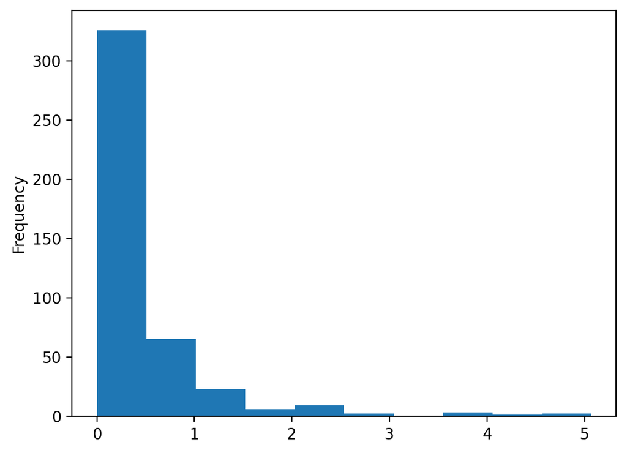

```python
midwest_new['asian_percent'].plot.hist()
```

#### 문제4

- 아시아 인구 백분율 전체 평균을 구하고, 평균을 초과하면 'large', 그 외에는 'small'을 부여한 파생변수를 만들어 보세요.

```python
average = midwest_new['asian_percent'].mean()
average
```

```
0.4872461834357345
```

```python
import numpy as np

midwest_new['group'] = np.where(midwest_new['asian_percent'] > average, 'large', 'small')
midwest_new
```

[output not shown]

#### 문제 5:

- 'large'와 'small'에 해당하는 지역이 얼마나 많은지 빈도표와 빈도 막대 그래프를 만들어 확인해 보세요

```python
count_group = midwest_new['group'].value_counts()
count_group
```

```
group
small    318
large    119
Name: count, dtype: int64
```

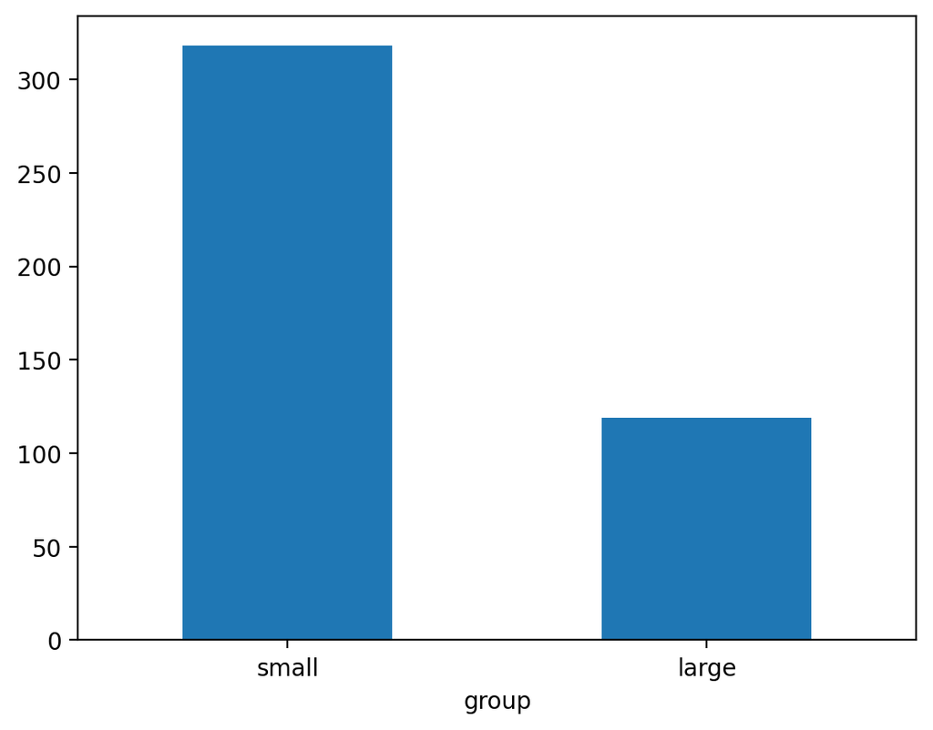

```python
count_group.plot.bar(rot = 0)
```

cf) 히스토그램과 막대그래프 1) 데이터 유형

- 히스토그램: 연속적인 수치 데이터를 다룹니다. 히스토그램은 변수의 분포를 보여주며, 일반적으로 수치적 데이터의 빈도수 또는 빈도 분포를 나타냅니다.
- 막대그래프: 범주형 데이터를 다룹니다. 각 범주는 서로 독립적이며, 각 범주의 빈도수나 양을 비교하는 데 사용됩니다.

2) 축

- 히스토그램: 수평축(x축)은 변수의 구간을 나타내며, 수직축(y축)은 빈도수 또는 밀도를 나타냅니다.
- 막대그래프: 수평축(x축)은 개별 범주를 나타내며, 수직축(y축)은 그 범주의 빈도수나 양을 나타냅니다.